# Engagement and Attendance Survey Report

Chris Martin

2023-08-08

Department of Psychology, University of Sheffield, August 2023

In June and July 2023 we carried out a survey of students enrolled on our undergraduate BSc Psychology programme to try to better understand student perceptions of course engagement and attendance. Approval for the research was provided by the Ethics Committee of the University of Sheffield.

This is a report on the results of that survey, produced using R Markdown.

This report contains preliminary analysis only. A full write up is in progress and we plan to submit the work for publication.

## Prepare environment and load data

Make the the qualtRics, likert and tidyverse libraries available and then load the data. Data is combined across the Level 1 and Level 2 surveys into a single data frame.

```r
library('qualtRics')
library('likert')
library('tidyverse')

L1data <- data.frame(read_survey("Psychology Student Engagement Survey 2023_20 July 2023_10.51.csv")) #load Level 1 data
L2data <- data.frame(read_survey("Level 2 Psychology Student Engagement Survey 2023_20 July 2023_15.30.csv")) #load Level 1 data
EngQs <- read.csv2("EngQs.csv", sep = ",") #load column names
Data <- rbind(L1data, L2data) #combine data
```

## Screen and clean data

Order dataframe by Qualtrics ‘progress’ value (from low to high) measure and inspect rows. Rows 20-26 are displayed below as they reveal the cut-off point between where respondents fail to complete the survey to the end, and those that do (where ‘progress’ is 97% or above).

```r
Data <- arrange(Data, Progress)
y<-data.frame(lapply(Data[c(20:26),c(4, 70:80)], substr, 1, 3))
y
```

```
##   Progress Q28_5 Q28_6 Q29_1 Q29_2 Q29_3 Q29_4 Q29_5 Q30_1 Q30_2 Q30_3 Q30_4
## 1       53  <NA>  <NA>  <NA>  <NA>  <NA>  <NA>  <NA>  <NA>  <NA>  <NA>  <NA>
## 2       53  <NA>  <NA>  <NA>  <NA>  <NA>  <NA>  <NA>  <NA>  <NA>  <NA>  <NA>
## 3       85   Agr   Dis   Dis   Nei   Nei   Str   Str  <NA>  <NA>  <NA>  <NA>
## 4       97   Agr   Nei   Dis   Dis   Agr   Agr   Str   Dis   Agr   Dis   Str
## 5       97   Str   Agr   Dis   Str   Str   Str   Dis   Dis   Dis   Nei   Nei
## 6       97   Str   Str   Str   Agr   Dis   Agr   Agr   Agr   Dis   Dis   Agr
## 7       97   Agr   Dis   Dis   Agr   Dis   Str   Dis   Agr   Agr   Dis   Agr
```

Up to and including row 22, there are missing values. Therefore, remove first 22 rows. Then apply longer column names to facilitate Likert data visualisation later.

```r
DataComplete <- Data[c(23:162),]
colnames(DataComplete)[c(5, 12:92)]<-EngQs[c(5, 12:92),3]
```

Next, show duration data (how long it took respondents to complete the survey).

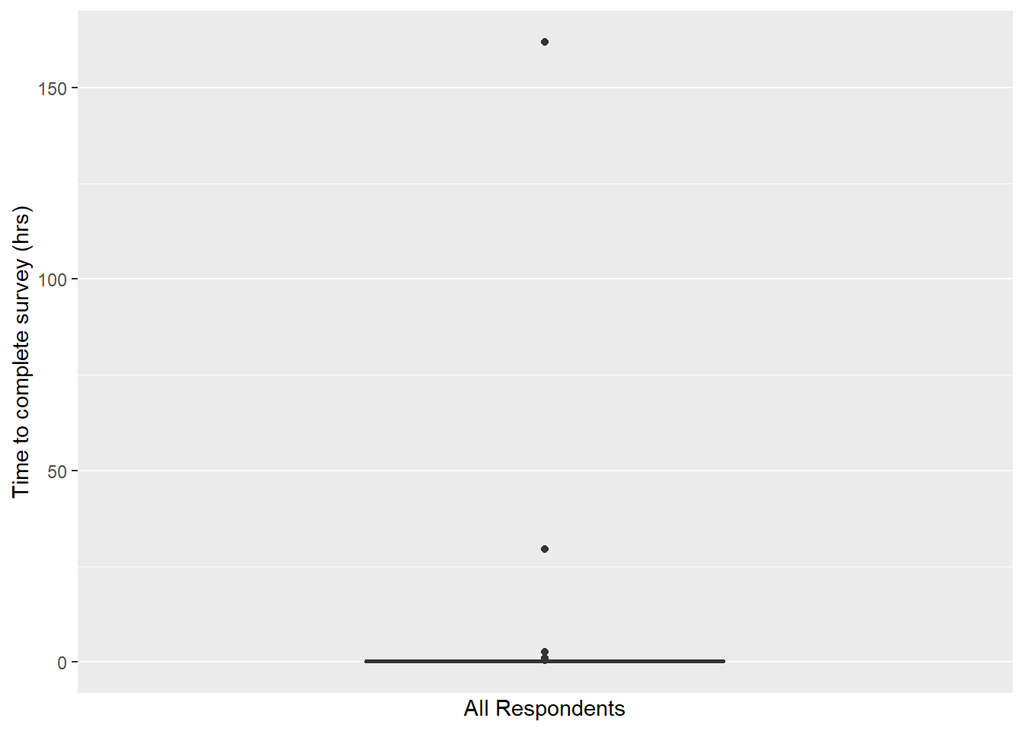

```r
ggplot()+
  geom_boxplot(aes(y=DataComplete$Duration/3600))+
  geom_jitter()+
  scale_x_discrete()+
  geom_boxplot(outlier.shape = NA)+
  ylab("Time to complete survey (hrs)")+xlab("All Respondents")
```

This reveals Two entries with very long duration to complete: inspection of the responses indicates no reason to exclude (likely that respondents partially completed the survey and come back to it on a later date).

## Demographics and other features

> Basic piechart for level of study

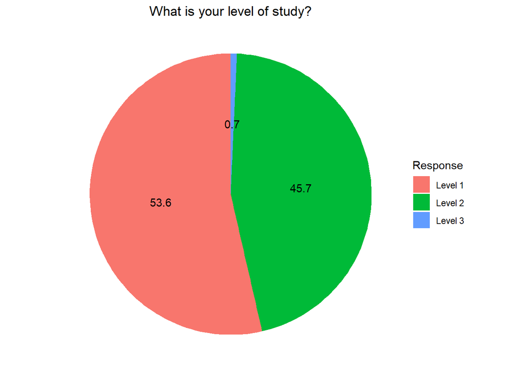

```r
ggplot(data.frame(table(DataComplete$Level)), aes(x="", y=Freq, fill=Var1))+
  geom_bar(stat="identity", width=1) +
  geom_text(aes(label = round(100*Freq/sum(Freq), digits=1)), position = position_stack(vjust = 0.5)) +
  coord_polar("y", start=0) +
  labs(title = "What is your level of study?", fill = "Response")+
  theme_void()+
  theme(plot.title = element_text(hjust = 0.5))
```

> Basic piechart for language

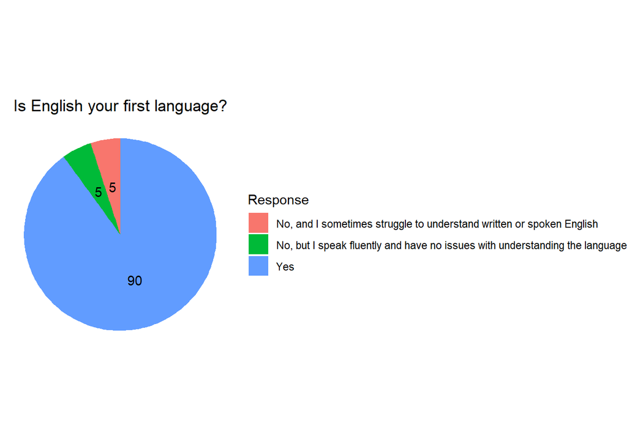

```r
ggplot(data.frame(table(DataComplete$Language)), aes(x="", y=Freq, fill=Var1))+
  geom_bar(stat="identity", width=1) +
  geom_text(aes(label = round(100*Freq/sum(Freq), digits=1)), position = position_stack(vjust = 0.5)) +
  coord_polar("y", start=0) +
  labs(title = "Is English your first language?", fill = "Response")+
  theme_void()+
  theme(plot.title = element_text(hjust = 0.5))
```

> Basic piechart for ethnicity

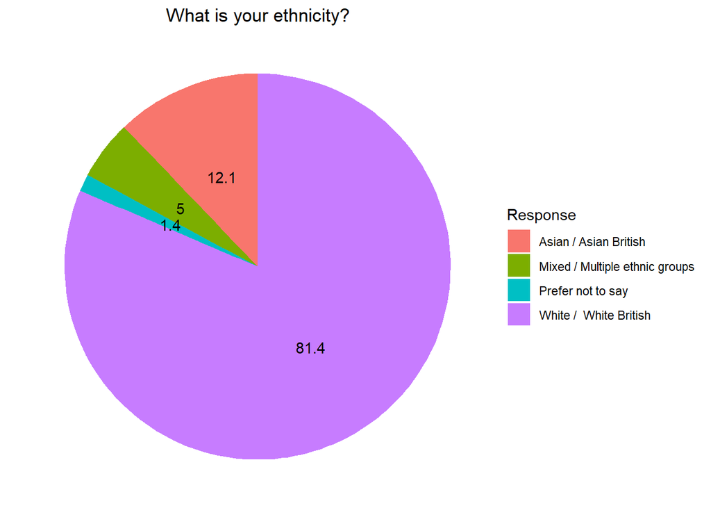

```r
ggplot(data.frame(table(DataComplete$Ethnicity)), aes(x="", y=Freq, fill=Var1))+
  geom_bar(stat="identity", width=1) +
  geom_text(aes(label = round(100*Freq/sum(Freq), digits=1)), position = position_stack(vjust = 0.5)) +
  coord_polar("y", start=0) +
  labs(title = "What is your ethnicity?", fill = "Response")+
  theme_void()+
  theme(plot.title = element_text(hjust = 0.5))
```

> Basic piechart for gender identity

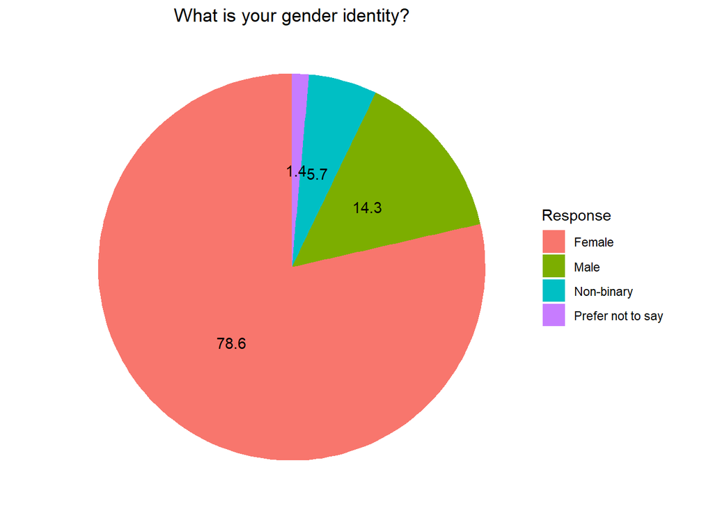

```r
ggplot(data.frame(table(DataComplete$Gender)), aes(x="", y=Freq, fill=Var1))+
  geom_bar(stat="identity", width=1) +
  geom_text(aes(label = round(100*Freq/sum(Freq), digits=1)), position = position_stack(vjust = 0.5)) +
  coord_polar("y", start=0) +
  labs(title = "What is your gender identity?", fill = "Response")+
  theme_void()+
  theme(plot.title = element_text(hjust = 0.5))
```

> Basic piechart for disabilities

**Cannot plot this yet. In the survey we allowed multiple response selections and these need to be parsed in the dataframe to enable clearer plotting.**

> Basic piechart for travel time

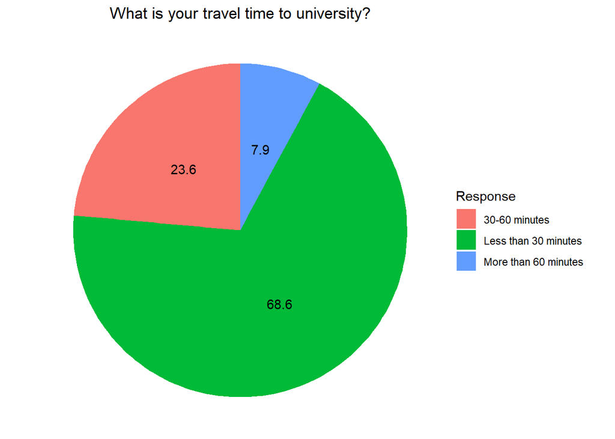

```r
ggplot(data.frame(table(DataComplete$Travel_Time)), aes(x="", y=Freq, fill=Var1))+
  geom_bar(stat="identity", width=1) +
  geom_text(aes(label = round(100*Freq/sum(Freq), digits=1)), position = position_stack(vjust = 0.5)) +
  coord_polar("y", start=0) +
  labs(title = "What is your travel time to university?", fill = "Response")+
  theme_void()+
  theme(plot.title = element_text(hjust = 0.5))
```

> Basic piechart for caring responsibilities

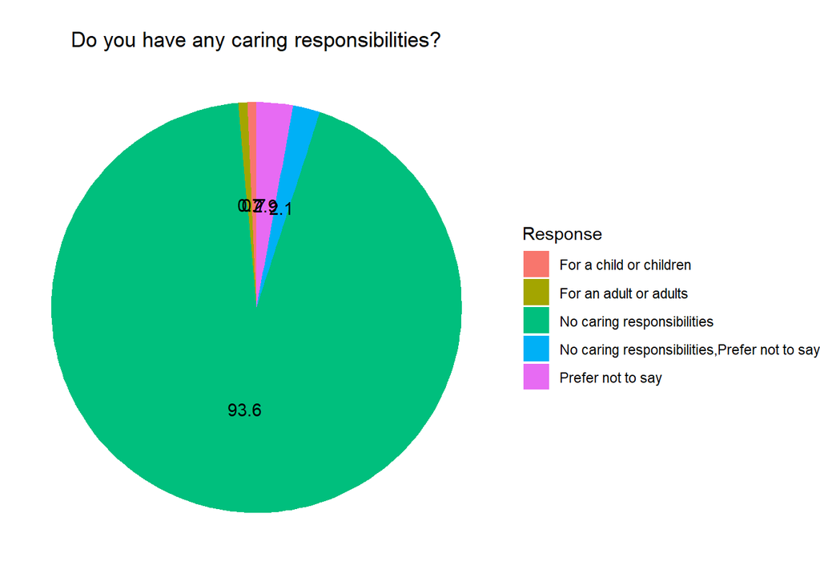

```r
ggplot(data.frame(table(DataComplete$Caring)), aes(x="", y=Freq, fill=Var1))+
  geom_bar(stat="identity", width=1) +
  geom_text(aes(label = round(100*Freq/sum(Freq), digits=1)), position = position_stack(vjust = 0.5)) +
  coord_polar("y", start=0) +
  labs(title = "Do you have any caring responsibilities?", fill = "Response")+
  theme_void()+
  theme(plot.title = element_text(hjust = 0.5))
```

> Basic piechart for international/home student status

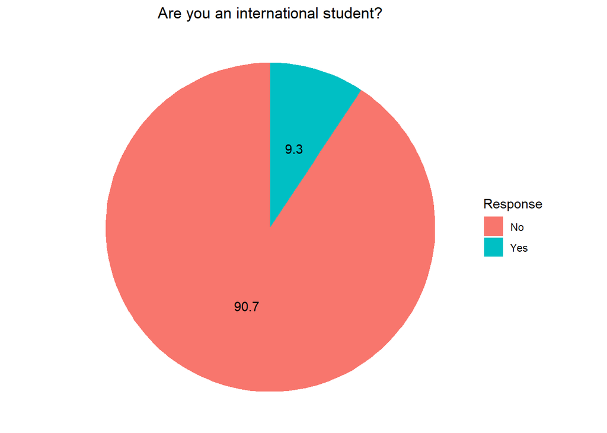

```r
ggplot(data.frame(table(DataComplete$International)), aes(x="", y=Freq, fill=Var1))+
  geom_bar(stat="identity", width=1) +
  geom_text(aes(label = round(100*Freq/sum(Freq), digits=1)), position = position_stack(vjust = 0.5)) +
  coord_polar("y", start=0) +
  labs(title = "Are you an international student?", fill = "Response")+
  theme_void()+
  theme(plot.title = element_text(hjust = 0.5))
```

> Basic piechart for mature student status

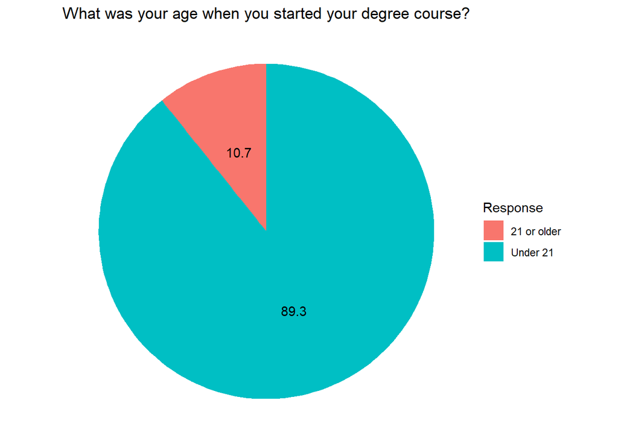

```r
ggplot(data.frame(table(DataComplete$Mature)), aes(x="", y=Freq, fill=Var1))+
  geom_bar(stat="identity", width=1) +
  geom_text(aes(label = round(100*Freq/sum(Freq), digits=1)), position = position_stack(vjust = 0.5)) +
  coord_polar("y", start=0) +
  labs(title = "What was your age when you started your degree course?", fill = "Response")+
  theme_void()+
  theme(plot.title = element_text(hjust = 0.5))
```

## Likert data for engagement perceptions

Show responses with items ordered from highest % of agreement to lowest % of agreement.

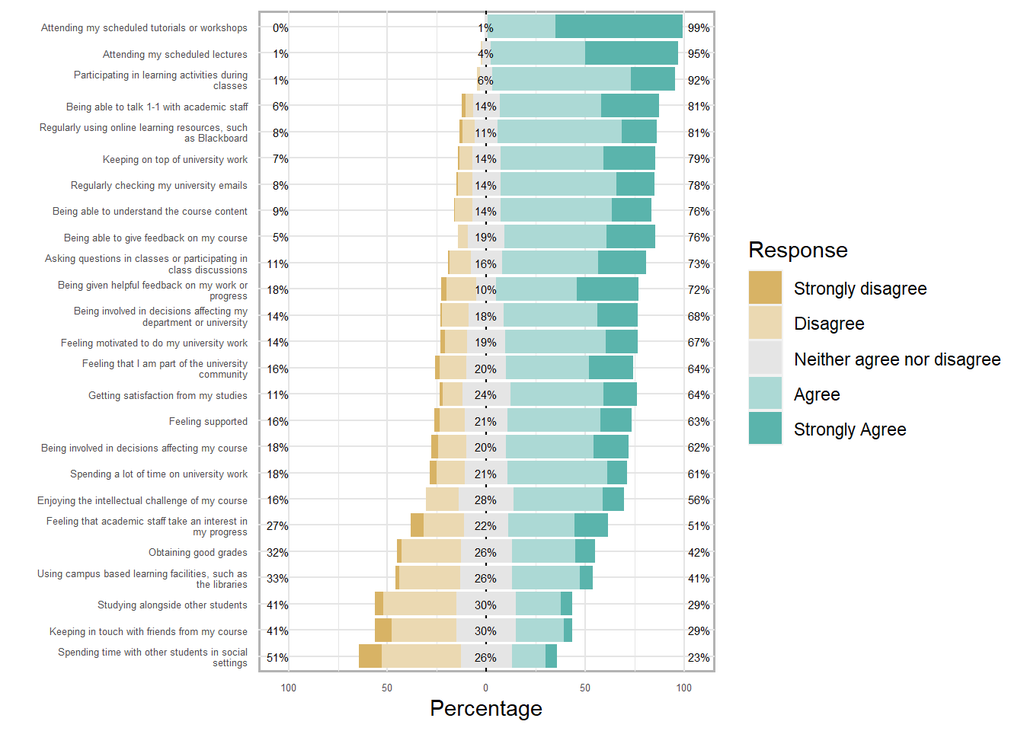

```r
#define factor levels for likert
liklev <- c("Strongly disagree", "Disagree", "Neither agree nor disagree", "Agree", "Strongly Agree")

#set factor and levels for engagement perceptions questions
for (x in 22:46) {
  DataComplete[,c(x)] <- factor(DataComplete[,c(x)], levels = liklev)
}

# plot(likert) perceptions of engagement
plot(likert(DataComplete[c(22:46)]), legend.position="right", text.size=2) +
  theme(axis.text=element_text(size=5)) +
  theme(panel.grid = element_line(color = "gray90"))
```

## Likert data for enabler/barrier items regarding in-person attendance

Show responses with items ordered from highest % of agreement to lowest % of agreement.

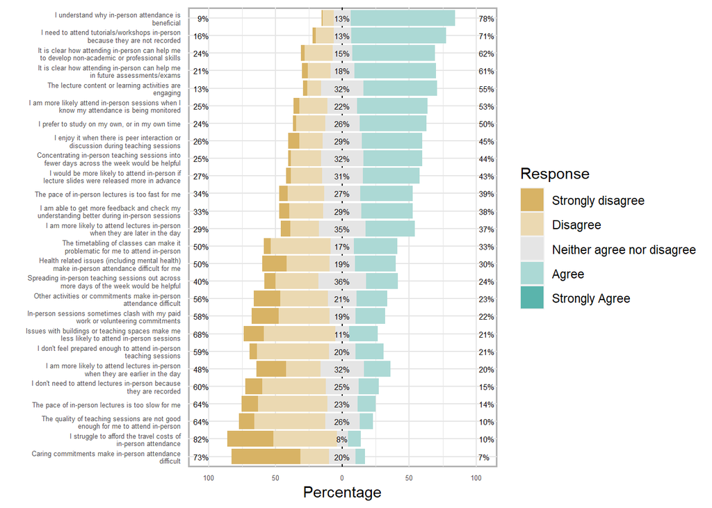

```r
#set factor and levels for enablers/barriers questions
for (x in 60:85) {
  DataComplete[,c(x)] <- factor(DataComplete[,c(x)], levels = liklev)
}

# plot(likert) enablers/barriers to attendance
plot(likert(DataComplete[c(60:85)]), legend.position="right", text.size=2) +
  theme(axis.text=element_text(size=5)) +
  theme(panel.grid = element_line(color = "gray90"))
```

**To consider: recode the above items to enable a plot organised on continuum of barrier-enabler. For example, the 7th item above (“prefer to study on my own”) would be reverse coded.**